# Eye Tracking - Social Engagement

Computational Modelling - Portfolio 1

Magnus Knudsen, Victor Møller, Anders Weile, Jan Kostkan, Carl-Magnus Christiansen

2019-02-22

Code At our Github

In addition, we hypothesize that these effects will also be modulated by sexual arousal. It is commonly accepted arousal affects (at least) pupil dilation, but we will also investigate whether it modulates the other outcome variables (fixation duration and saccade velocity). We will also test whether time modulates these effects.

We propose the following three hypotheses:

- H1: Pupil size will increase in situations affording social responses and when there is sexual arousal and over time.
- H2: Fixation duration will increase in situations affording social responses and when there is sexual arousal and over time.
- H3: Saccade velocity will increase in situations affording social responses and when there is sexual arousal and over time.

# Operationalization

Situations affording social responses is here defined as conditions involving ostension and directedness elicited by an actor in a video that the participant is watching. Both of these main effects (and their interaction) are hypothesized to increase interaction/sociality.

Sexual arousal is here defined as conditions in which the sexual preference of the participant matches the gender of the presenter. This assumes that (1) the gender of the participant is indicative of sexual preference and that (2) the participant finds the actor in the videos sexually interesting. Neither of these assumptions where checked which is a flaw of the experimental design (if this hypothesis is to be pursued).

Time is simply the effect of time in each trial (just over 6 seconds). We suggest that there might be some effect, but we do not offer specific hypotheses as to why.

# Methods

## Experiment description

In this experiment, participants were shown short five second videos with an actor sitting by a table with a cup, either privately manipulating the cup, or lifting his head and making eye contact before manipulating the cup. The actor either looked at the participant (directly into the camera) or to a third person outside the camera’s field of view, yielding two-by-two factorial design with ostension and directedness as main effects. The gender of the actor was also changed between male and female to control for gender effects. Between each picture there was a fixation across, and the participant was shown eight images, each unique image one time per participant.

We used an EyeLink table-mounted eye tracker, approximately 60cm away from the screen, recording with a sampling rate of a 1000hz.

## Preprocessing

Choosing parameters for visual events, i.e. what the eye-tracker counted as a saccade and a fixation, was our first cause of concern. There are no rigid definitions of what constitutes different events in eye-tracking research, though some proposed thresholds are given in the literature. Often, researchers copy the parameters used in previous experiments to have a baseline to which they can compare their results. We choose parameters on the less conservative end.

We used a rolling window of 200 ms to compute the “probability” of each data point to be in a fixation or a saccade. We then chose a threshold of probability (.85) in order for something to be considered a fixation or a saccade.

Fixations and saccades were calculated from mean velocities, defining saccades as exceeding a threshold of 15 degrees per second in a window of 200 ms while fixations were defined as being below this threshold.

If we were trying to replicate the study in the “real world”, we would of course use the same parameters, given by the Eyelink software. But since this was an exercise, we thought it better to use something that wasn’t a blackbox to us.

Recordings were of either left or right eye, depending on participant’s eye dominance. As no participant had both their eye tracked, these records could be combined into a single record of the dominant eye. Resulting data were then used to estimate events.

**H1 + H2 (Fixations_SE column):** One participant had a significantly longer trial than the other participants. We chose to delete data points that were outside of the length of the other trials (which were relatively uniform). We also created two new columns: A new variable (condition) was created with four levels (combinations of ostension and direction). The creation of the new variable was mainly for clarity in plotting. A new variable (arousal) was created with two levels (yes, no). Here “yes” corresponds to an incongruency between gender of participant and gender of presenter and “no” corresponds to congruency.

ParticipantID: 2018-1_2_f

**H3 (Saccades_SE column):** We deleted corresponding data from ParticipantID: 2018-1_2_f in this data set as the same problem was present. We also created the two variables from the Fixations_SE data set (condition, arousal). Additionally we created a new variable (MeanVelocity) based on the previous columns MeanVelocityX and MeanVelocityY. This was done to obtain the dependent variable.

### Preliminary plots

We chose to plot the dependent variables (pupil size, fixation duration and saccade velocity) before running models to check their distribution. Fixation duration and saccade velocity follow power-law distributions & we will use the log-link function in the subsequent models to make up for this. Pupil size follows a bi-modal distribution (across participants). Note that pupil size is relatively normally distributed for each participant. Since each participant are allowed their own intercept and slope we believe this to ameliorate this breach of normality. We chose to simply model this outcome variable normally with a random effects model.

We were not quite sure how to deal with this.

If this response variable is modeled with log-link then the results are physically impossible & uninterpretable

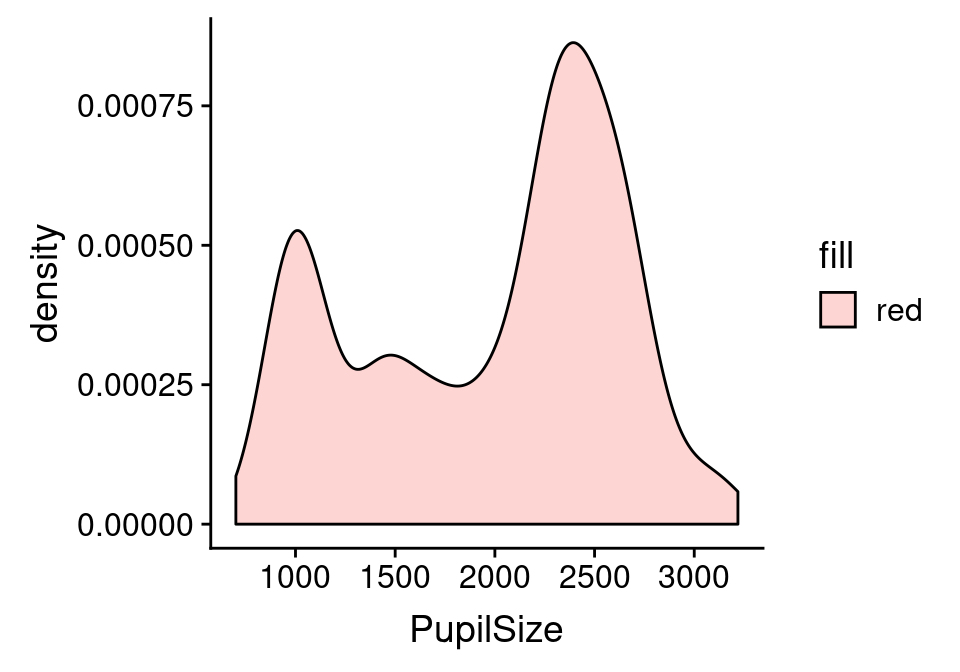

Pupil size distribution (global)

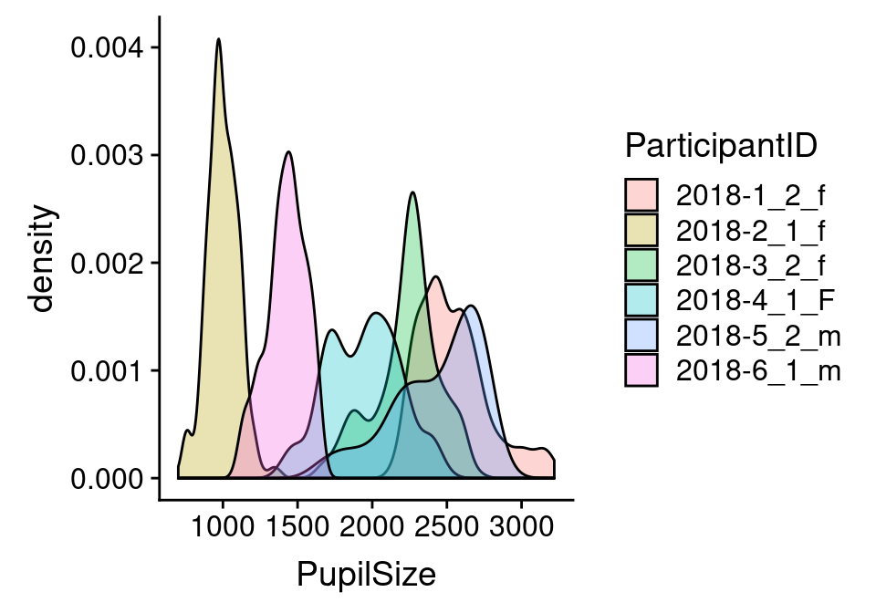

Pupil size distribution per participant

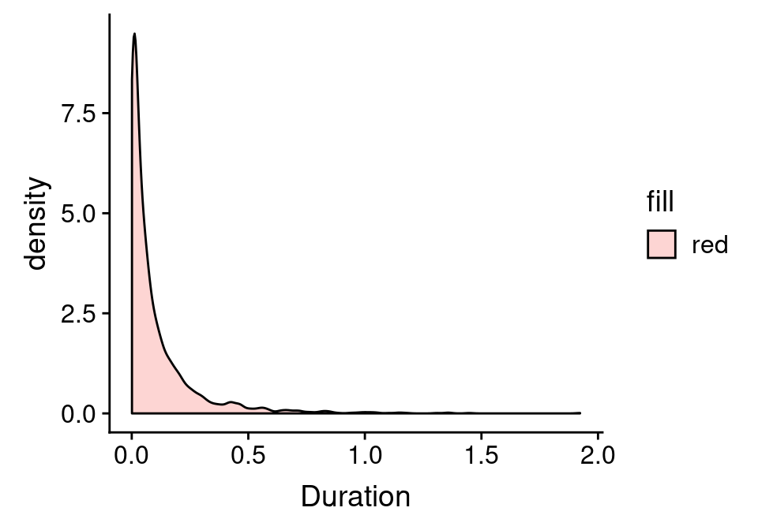

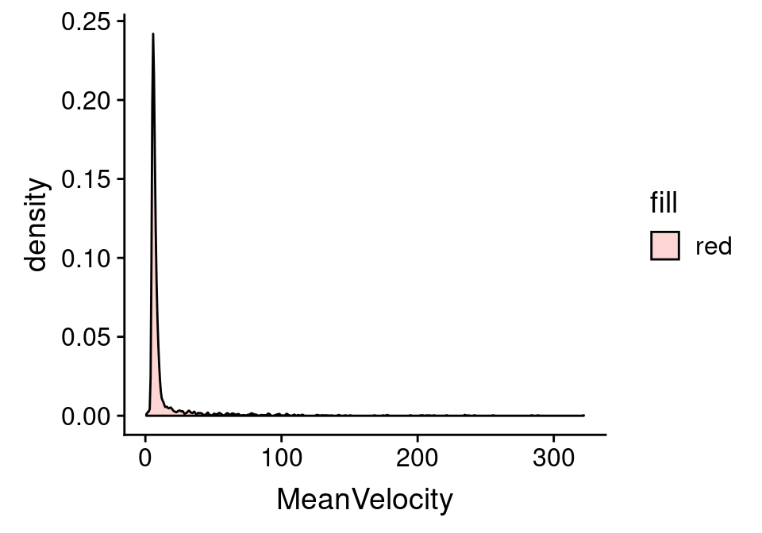

Distribution of Mean Saccade Velocity ( global )

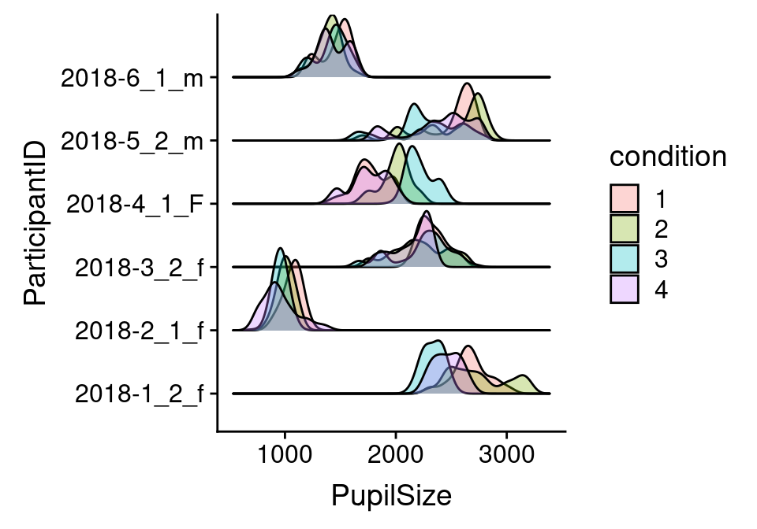

H1 - ridges showing why condition (ostension and directedness) is not significant

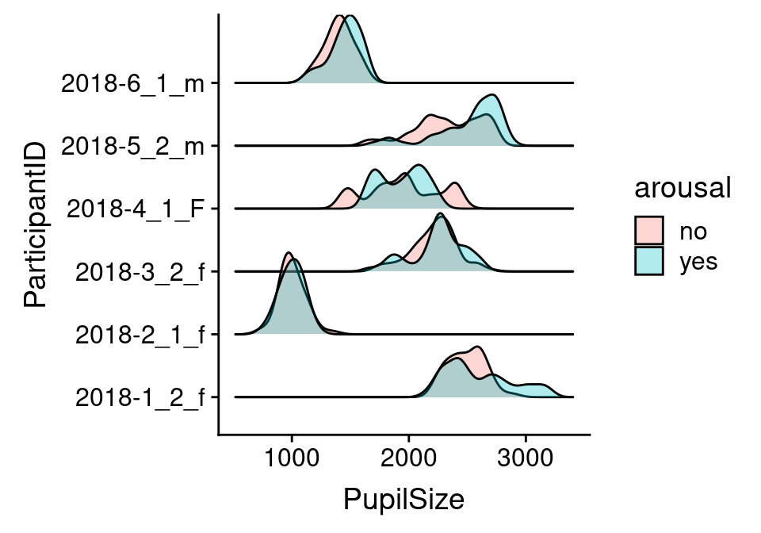

H1 - ridges showing why gender/experimenter is not significant

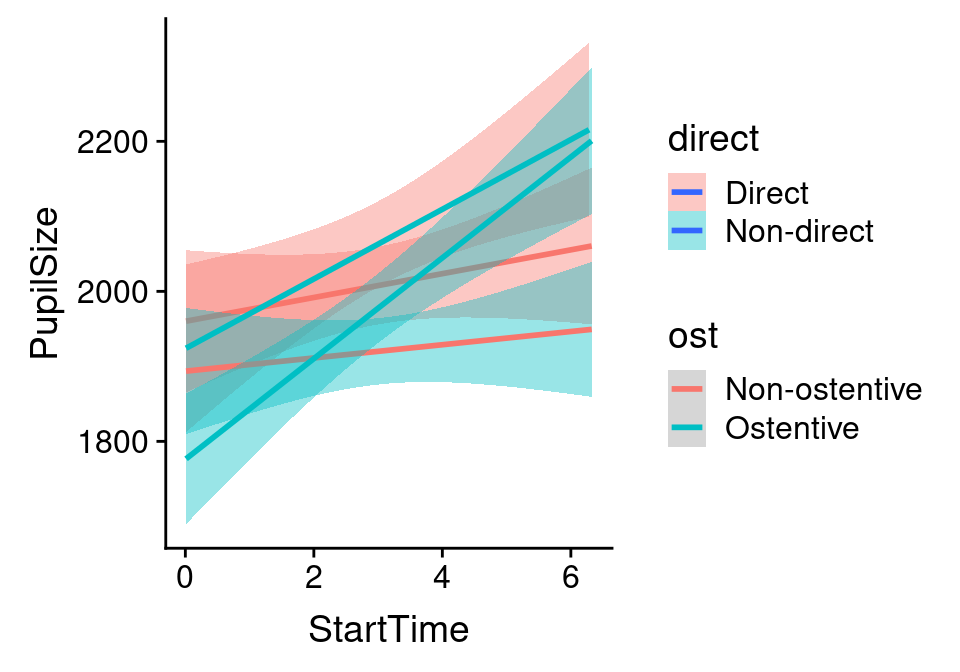

H1 - ostension and directedness over time.

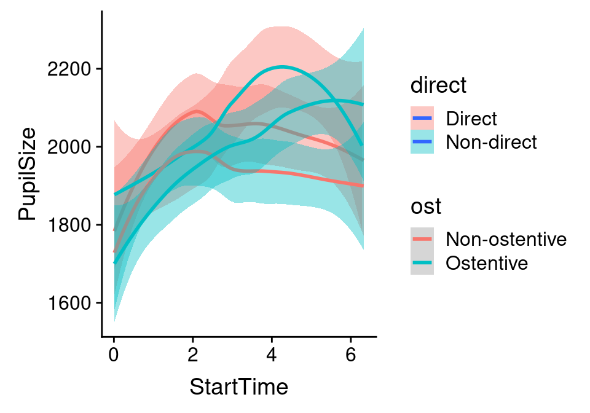

H1 - loess, showing that the slopes are not in fact linear (only in the small world of the model

## Models (hypothesis testing)

From H1, H2 & H3 we know that pupil size, fixation duration and saccade velocity should be the *dependent variables* of our models.

**Fixed effects:** Qua our experimental design, we have ostension and directedness as fixed effects. These are hypothesized to interact based on Tylén et al. (2012), in which an interaction was not found but also hypothesized. We chose to create and include arousal (sexual) as fixed effects in the model as well. The idea is that a presenter of the opposite sex will sexually arouse the participant. We also included time in our model as a fixed effect to test for consistent differences in pupil dilation, fixation duration and saccade velocity over time.

Since we are testing for the same effect (interaction vs. observation, arousal & time) on different outcome variables, we kept the fixed effects and random structure constant and only changed the outcome variable from H1 to H2 to H3.

**H1:** Pupil size follows a bi-modal distribution globally (I.e., when combining participants). However, as we let participants vary in our random effects structure we believe that this might be modeled away. The distributions per participant are noisy but do not look to dissimilar from a normal distribution. We chose to simply apply a normal GLMM. NB: A google search on how to fit models on a bimodally distributed outcome variable did not return any easy/good solutions.

**H2:** Based on the power-law distribution of the outcome variable (fixation duration) we chose to model with the log-link function. This compresses the small values and expands the large values and ensures that we do not get negative results (I.e., fixation duration by definition cannot occur over negative time).

**H3:** Based on the power-law distribution of the outcome variable (saccade velocity) we chose to model with the log-link function. This compresses the small values and expands the large values and ensures that we do not get negative results (I.e., saccade velocity by definition cannot be a negative value).

## Participants

This experiment included 6 participants (m = 2, f = 4) from the 2018 run of the experiment. Their exact ages are unknown but they are believed to range between 20-25 years of age, since they were 3rd semester bachelor students at the time of data collection.

# Results

**H1:** Multiple regression analysis was used to predict pupil size by directedness and ostension (and their interaction), time and arousal (sexual). Only time (start time) was found to significantly predict pupil dilation (b = 45.46, **t(4.80)** = 3.91, p < .05). For each second of the experiment the diameter of the pupil increases by 45.46 **on average.** **The main effects of directedness, ostension, arousal and all interactions were found non-significant.

Hypothesis 1 Model

|  | Pupil Size |  |  |
| --- | --- | --- | --- |
| Predictors | Estimates | CI | p |
| (Intercept) | 1808.53 | 1195.50 – 2421.57 | **0.005** |
| ostOstentive | 18.91 | -89.95 – 127.76 | 0.747 |
| directNon-direct | -51.49 | -271.63 – 168.65 | 0.666 |
| StartTime | 45.46 | 22.70 – 68.22 | **0.012** |
| arousalyes | 52.03 | -10.95 – 115.00 | 0.168 |
| ostOstentive:directNon-direct | -68.06 | -310.68 – 174.55 | 0.606 |
| Observations | 2534 |  |  |

Hypothesis 2 Model

|  | Duration |  |  |
| --- | --- | --- | --- |
| Predictors | Estimates | CI | p |
| (Intercept) | -2.46 | -2.75 – -2.16 | **<0.001** |
| ostOstentive | -0.01 | -0.22 – 0.20 | 0.938 |
| directNon-direct | -0.01 | -0.15 – 0.14 | 0.930 |
| StartTime | 0.03 | 0.00 – 0.06 | **0.037** |
| arousalyes | -0.03 | -0.20 – 0.14 | 0.718 |
| ostOstentive:directNon-direct | 0.08 | -0.14 – 0.31 | 0.460 |
| Observations | 2534 |  |  |
| Marginal R<sup>2</sup> / Conditional R<sup>2</sup> | 0.065 / 0.673 |  |  |

| R2m | R2c |
| --- | --- |
| 0.0442632 | 0.7776373 |

**H3:** Multiple regression analysis was used to predict saccade velocity by directedness and ostension (and their interaction), time, and arousal (sexual). All main effects and interactions were found non-significant.

Hypothesis 3 Model

|  | Mean Velocity |  |  |
| --- | --- | --- | --- |
| Predictors | Estimates | CI | p |
| (Intercept) | 3.53 | -6.98 – 14.04 | 0.511 |
| ostOstentive | 0.22 | -7.01 – 7.46 | 0.952 |
| directNon-direct | -0.12 | -7.26 – 7.02 | 0.974 |
| StartTime | 0.02 | -0.05 – 0.09 | 0.648 |
| arousalyes | -0.22 | -1.42 – 0.99 | 0.724 |
| ostOstentive:directNon-direct | -0.18 | -8.56 – 8.20 | 0.966 |
| Observations | 2526 |  |  |

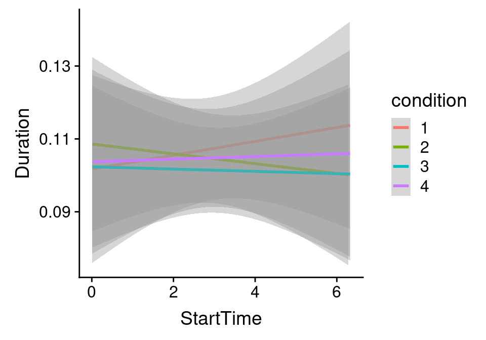

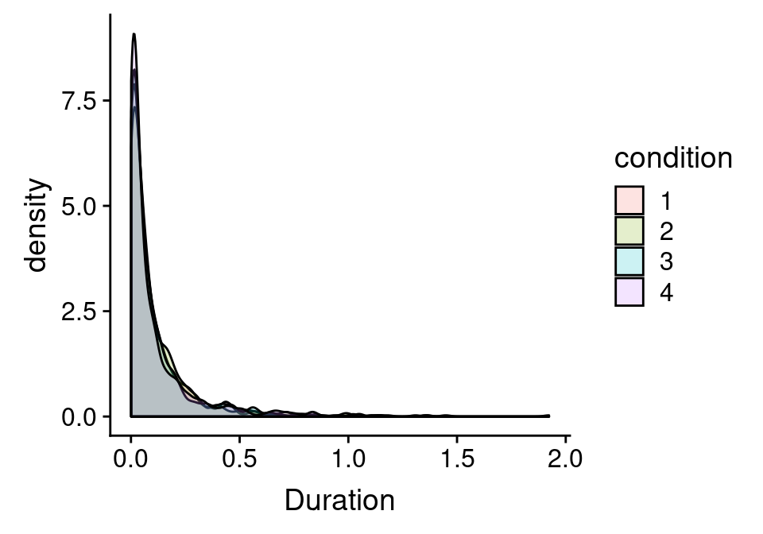

H2 - Density plot of fixation duration by condition

# Discussion & conclusion

**H2:** The model suggests that time (start time) is a significant predictor of fixation duration. However, the effect is very small and the sample size is very small. We do not place to much weight on this finding.

**H3:** Nothing was significant.

**Generally:** The fact that we did not find an effect of interaction over observation (ostension & directedness) on any outcome variable suggests either (1) too little power to detect an effect, (2) that we obtained a false-negative or (3) that there is no effect. It is certainly the case that the reported study is underpowered (n = 6) to find the hypothesized effect at a satisfactory rate (80%). *That this is the case could be tested.* All in all the study cannot conclusively add to our knowledge of how socially engaging situations affect the physiological outcome varibles that were investigated.